# A mini R Package!

PubH 7462 - Week 10 Activity

In this activity, we will walk you through a step-by-step exercise to create a mini R-package `Temp` that converts temperatures from Fahrenheit degree to Celsius degree and vice versa. Contents for this exersise are adapted from https://ourcodingclub.github.io/tutorials/writing-r-package/

### Step 0: Getting Ready

Load (or install then load) two R packages that are commonly used to create R packages:

```r
install.packages('devtools')
install.packages('roxygen2')
```

To get started, run a line of commmand `devtools::create("pathtopackage/pkgname")` in the console. You will see from the messages that several folders and files are created:

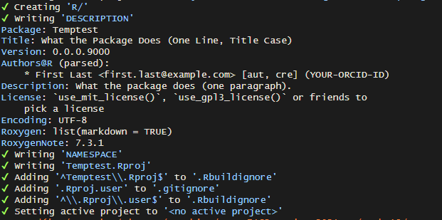

Make sure that you navigate to the folder `"pathtopackage/pkgname"` and open the pkgname.Rproj and begin working from there.

An alternative approach is to get started “by hand”. You can set up your new R package by creating a new R project: File > New Project > New Directory > R Package >

[figure not shown]

After you click the “Create Project” button, you will see some fundamental files and folders created for the new `Temp` R package. If you get to this step by the “by hand” process, you will see a “hello.R” file created under the `R/` folder, and a “hello.Rd” file under the `man/` folder. Please remove these before you proceed.

### Step 1: Edit the `R/` directory

Create a new R file “temp_fun.R” under the `R/` folder and add the two following functions to the “temp_fun.R” file:

```r
F_to_C <- function(F_temp){
    C_temp <- (F_temp - 32) * 5/9
    return(C_temp)
}

C_to_F <- function(C_temp){
    F_temp <- (C_temp * 9/5) + 32
    return(F_temp)
}
```

### Step 2: Add `roxygen2` syntax

While you can add documentation for your R package mannually step-by-step, the `roxygen2` package helps you automate the documentations process. To use `roxygen2` , you will need to insert the following syntax in front of the functions that you created in the “temp_fun.R” file:

```r
#' Fahrenheit conversion
#'
#' Convert degrees Fahrenheit temperatures to degrees Celsius
#' @param F_temp The temperature in degrees Fahrenheit
#' @return The temperature in degrees Celsius
#' @examples
#' temp1 <- F_to_C(50)
#' temp2 <- F_to_C( c(50, 63, 23) )
#' @export
F_to_C <- function(F_temp){
    C_temp <- (F_temp - 32) * 5/9;
    return(C_temp);
}

#' Celsius conversion
#'
#' Convert degrees Celsius temperatures to degrees Fahrenheit
#' @param C_temp The temperature in degrees Celsius
#' @return The temperature in degrees Fahrenheit
#' @examples
#' temp1 <- C_to_F(22)
#' temp2 <- C_to_F( c(-2, 12, 23) )
#' @export
C_to_F <- function(C_temp){
    F_temp <- (C_temp * 9/5) + 32;
    return(F_temp);
}
```

After these syntax are added to the “temp_fun.R” file, run the following R code (make sure that you navigate to the working directory for your new R package. Otherwise you may get error messages):

```r
roxygen2::roxygenise()
```

Now open the `NAMESPACE` file, you will see two items were added:

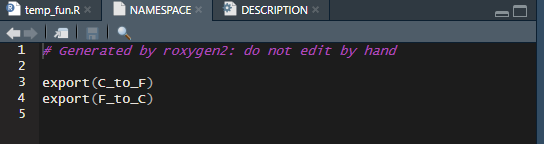

Go into the `man` folder, there are two files added by `roxygen2` :

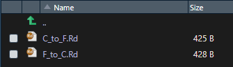

### Step 3: Edit the `DESCRIPTION` file

You may recall from the lecture that there is also a `DESCRIPTION` file! There are some default texts added to the `DESCRIPTION` file already. Modify the texts so that it makes more sense!

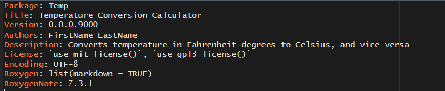

Note: if you use the command line approach to get started, you will see a `person()` function in line for `Authors`. This function tends to give errors. You can replace that with just your FirstName and LastName.

Whenever you make some updates to the documentation, remember to run `devtools::document()`

### Step 4: Install and Distribute

Now let’s try out your new R package!

Start a new R session and navigate to the working directory that is one level above your R package directory. And run the following code:

```r
library(devtools)
install("Temp")
library(Temp)
```

Now check out your functions!

```r
#check out the help page that was created by roxygen2:
?F_to_C
#check today's highest temperature
F_to_C(62)
C_to_F(17)
```

You may have seen R packages packed into tar.gz files. You can obtain this tar.gz file by using the `build()` function from the `devtools` . When you run the `build()` command, make sure that you set the working directory to be directory of your R package.

```r
setwd("pathtopackage/pkgname")
devtools::build()
```

**This should create a tar.gz file for your package in your directory. Upload this file to Canvas to get credit for the activity.** If you have time, experiment with adding other functions to your package or expanding on the descriptions!

Another great tool to distribute your R-package is via GitHub! To learn more about how to create a GitHub repository for your R package, you can follow Step 6 through 9 on this post:

https://r-mageddon.netlify.app/post/writing-an-r-package-from-scratch/